# Structured Dropout

We would like to test Structured dropout method on MNIST data, in terms of the effect on generalisation, and the effect on the correlations of the units. We will use several architectures to test the method :

```python
import numpy as np
import tensorflow as tf
from keras.datasets import mnist
from keras.utils import to_categorical
import matplotlib.pyplot as plt
import seaborn as sns
from IPython.display import set_matplotlib_formats
set_matplotlib_formats('png')
#import os
#os.environ['CUDA_VISIBLE_DEVICES'] = "0"
```

#### Load data

```python
# classification data

# classification data
nb_classes = 10
batch_size = 32

# the data, split between train and test sets
(x_train, y_train), (x_test, y_test) = mnist.load_data()
#(x_train, y_train), (x_test, y_test) = cifar100.load_data()

# input image dimensions
img_rows, img_cols  = x_train.shape[1:]
dimension = img_rows * img_cols
dim=dimension
nb_train = x_train.shape[0]
nb_test = x_test.shape[0]

x_train = x_train.reshape(nb_train, dimension)
x_test = x_test.reshape(nb_test, dimension)

x_train = x_train.astype('float32')
x_test = x_test.astype('float32')
x_train /= 255
x_test /= 255

print('x_train shape:', x_train.shape)
print(nb_train, 'train samples')
print(nb_test, 'test samples')

# Convert class vectors to binary class matrices.
y_train = to_categorical(y_train, nb_classes)
y_test = to_categorical(y_test, nb_classes)
```

```
x_train shape: (60000, 784)
60000 train samples
10000 test samples
```

#### Models

While iid dropout on one layer amounts to multiply the activations of that layer by independent bernoulli variables while training, Structured dropout amounts to multiply the activations of that layer by bernoulli variables with a non-diagonal matrix. The activations of the input layer is the input data. Since sampling from multivariate bernoulli with a given covariance is known to be a difficult problem, and since multiplicative gaussian dropout works as well as dropout we sample from multivariate Gaussian using the Cholesky decompoistion (embedded in Tensorflow).

```python
from tensorflow.contrib.distributions import MultivariateNormalFullCovariance as mvnfc


def dropout_layer(x, mode, l, dim):

    if mode == 'struc':
       #mu = tf.Variable(lambda : tf.ones(shape=[dim]))
        xm = tf.reduce_mean(x, 0)
        cov = tf.matmul(tf.transpose(x-xm), x-xm) / batch_size
        cov += 1e-2 * tf.eye(dim, dtype='float32')
        sample = mvnfc(tf.zeros(shape=[dim]), cov).sample()
        return tf.multiply(x, np.sqrt(l)* sample + tf.ones(shape=[dim]))

    elif mode == 'iid_gauss':
      # mu = tf.Variable(lambda : tf.ones(shape=[dim]))
        cov =  tf.eye(dim, dtype='float32')
        sample = mvnfc(tf.zeros(shape=[dim]), cov).sample()
        return tf.multiply(x, np.sqrt(l)* sample + tf.ones(shape=[dim]))
    elif mode == 'iid_bern':
      # mu = tf.Variable(lambda : tf.ones(shape=[dim]))

#         cov =  tf.eye(dim, dtype='float32')
        p_mat = tf.constant(1/(1+l), shape=(batch_size, dim))
        sample = tf.contrib.distributions.Bernoulli(probs=p_mat, dtype='float32').sample()
        return tf.multiply( (l+1)* x, sample )
    else:  # no dropout
        return x
```

- On both layers
- Only on the input layer
- Only on one of the hidden layers

We try a 2-hidden layer network, perform once dropout on the first hidden layer only, and second on the second hidden layer only, and a last experiment where we only apply dropout and our structured dropout on the input layer only, and check if the 2 hidden layers will be decorrelated.

```python
nb_hidden1= 256
nb_hidden2= 10
dim=dimension

class MLP_2:

    def __init__(self, dim, nb_hidden1,nb_hidden2, nb_classes, batch_size, l, mode=None):

        self.X = tf.placeholder(tf.float32, [None, dimension])
        self.Y = tf.placeholder(tf.float32, [None, nb_classes])
        self.train = tf.placeholder(tf.bool)

        W1 = tf.Variable(tf.random_uniform([dim, nb_hidden1], -0.01, 0.01))
        b1 = tf.Variable(tf.zeros(shape=[nb_hidden1]))

       #self.dl1 = tf.cond(self.train, lambda : dropout_layer(self.X, mode, l, dimension), lambda : self.X)
        self.dl1 = self.X
        self.err1 = self.dl1 - self.X
        self.act1 = tf.nn.relu(tf.matmul(self.dl1, W1) + b1)

        W2 = tf.Variable(tf.random_uniform([nb_hidden1, nb_hidden2], -0.01, 0.01))
        b2 = tf.Variable(tf.zeros(shape=[nb_hidden2]))

        self.dl2 = tf.cond(self.train, lambda : dropout_layer(self.act1, mode, l, nb_hidden1), lambda : self.act1)
        self.err2 = self.dl2 - self.act1
        self.act2 = tf.nn.relu(tf.matmul(self.dl2, W2) + b2)

        W3 = tf.Variable(tf.random_uniform([nb_hidden2, nb_classes], -0.01, 0.01))
        b3 = tf.Variable(tf.zeros(shape=[nb_classes]))

        #x = tf.cond(self.train, lambda : dropout_layer(self.act2, mode, l, nb_hidden2), lambda : self.act2)
        x=self.act2
        x = tf.matmul(x, W3) + b3

        # Minimize error using cross entropy
        self.probs = tf.nn.softmax(x)
        log_loss = tf.nn.softmax_cross_entropy_with_logits_v2(logits=x, labels=self.Y)
        self.mean_log_loss = tf.reduce_mean(log_loss)


def training(seqlambda, mode, max_iters=6000, learning_rate=1):

    all_accuracies = []
    all_cov_norms1 = []
    all_cov_norms2 = []
    acts1 = []
    acts2 = []


    for lamb in seqlambda:

        print('Lamb', lamb)
        accs = [] ; cov_norms1 = [] ;  cov_norms2 = [] ;

        model = MLP_2(dim, nb_hidden1,nb_hidden2, nb_classes, batch_size, lamb, mode)

        # training parameters
        optimiser = tf.train.AdamOptimizer().minimize(model.mean_log_loss)

        with tf.Session() as sess:

            sess.run(tf.global_variables_initializer())

            for iters in range(max_iters):

                idx = np.random.randint(nb_train, size=batch_size)

                _, loss = sess.run([optimiser, model.mean_log_loss], feed_dict={
                    model.X : x_train[idx], model.Y : y_train[idx], model.train : True})
                #print(np.sum(err1))
                #print(np.sum(err2))


                if iters % 200 == 0:
                    print('Iteration: %d, %.03f' % (iters, loss))
                    pred, act1,act2= sess.run([model.probs, model.act1,model.act2],
                                    feed_dict={model.X : x_test, model.train : False})                    #print(np.sum(err1))
                    #print(np.sum(err2))
                    acc = np.sum(np.argmax(pred, axis=1) ==
                                 np.argmax(y_test, axis=1)) / float(nb_test)
                    accs.append(acc)
                    cov_norms1.append(np.linalg.norm(np.corrcoef((act1 + 1e-16 * np.random.rand(*act1.shape)).T)))
                    cov_norms2.append(np.linalg.norm(np.corrcoef((act2 + 1e-16 * np.random.rand(*act2.shape)).T)))

                #    print(cov_norms1[-1])
                #    print(cov_norms2[-1])
                    print('Accuracy: %.03f' % acc)

            all_accuracies.append(accs)
            all_cov_norms1.append(cov_norms1)
            all_cov_norms2.append(cov_norms2)
            acts1.append(act1)
            acts2.append(act2)

    return all_accuracies, all_cov_norms1, acts1,all_cov_norms2, acts2

max_iters = 20000
lambdas = [1e-4,1e-2,1e-0]


print('#### No dropout ####')
acc_linear, cor_linear_1 , acts1_linear,cor_linear_2 , acts_linear_2 = training([None], None, max_iters)

print('#### Structured dropout ####')
acc_struc, cor_struc_1, acts1_struc, cor_struc_2 , acts_stuc_2= training(lambdas, 'struc', max_iters)

print('#### IID dropout ####')
acc_iid,cor_iid_1, acts1_iid, cor_iid_2 , acts_iid_2= training(lambdas, 'iid_gauss', max_iters)

print('#### IID bern dropout ####')
acc_iid_bern,cor_iid_1_bern, acts1_iid_bern, cor_iid_2_bern , acts_iid_2_bern = training(lambdas, 'iid_bern', max_iters)
```

[output not shown]

```python
sns.reset_orig()

fig, ax = plt.subplots(figsize=(10, 8))

ax.plot(np.arange(200, max_iters, 200), acc_linear[0][1:], linestyle='-.',
        linewidth=1, color='red', label='no dropout')

line_styles = ['--o', '--*']


best_iid = np.argmax([np.max(accs) for accs in acc_iid])

ax.plot(np.arange(600, max_iters, 200), acc_iid[best_iid][3:],
            line_styles[1], color='green', linewidth=1,
            label=r'iid. Gauss. dropout, $\lambda=$%.0e' % lambdas[best_iid])


best_iid_bern = np.argmax([np.max(accs) for accs in acc_iid_bern])

ax.plot(np.arange(600, max_iters, 200), acc_iid[best_iid_bern][3:],
            line_styles[1], color='purple', linewidth=1,
            label=r'iid. Bern. dropout, $\lambda=$%.0e' % lambdas[best_iid])


best_struc = np.argmax([np.max(accs) for accs in acc_struc])

ax.plot(np.arange(600, max_iters, 200), acc_struc[best_struc][3:],
            line_styles[1], color='blue', linewidth=1,
            label=r'struc. Gauss. drop. (ASNI), $\lambda=$%.0e' % lambdas[best_struc])



ax.set_xlabel('iteration')
ax.set_ylabel('accuracy')

# ax.set_ylim([0.8, 1.0])

plt.legend(prop={'size': 18})
plt.show()
```

[output not shown]

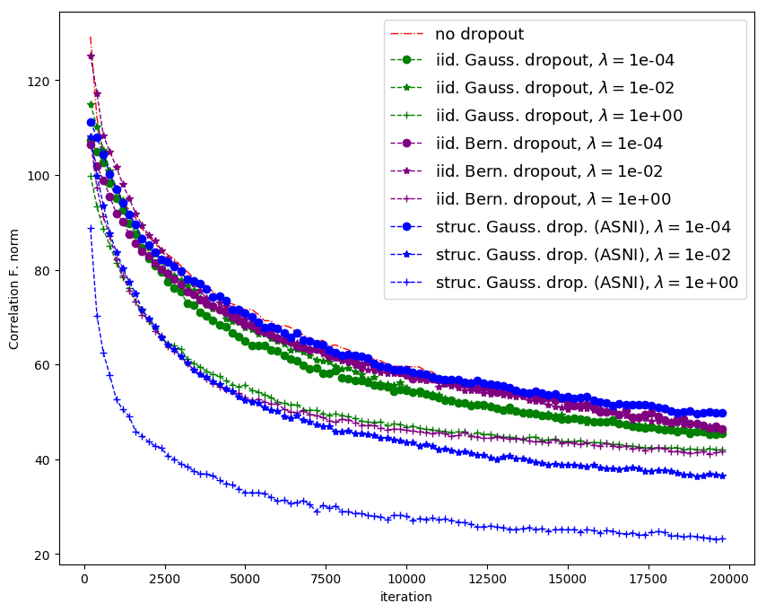

```python
sns.reset_orig()


fig, ax = plt.subplots(figsize=(10, 8))

ax.plot(np.arange(200, max_iters, 200), cor_linear_1[0][1:], linestyle='-.',
        linewidth=1, color='red', label='no dropout')

line_styles = ['--o', '--*', '--+']


for i, series in enumerate(cor_iid_1):
    ax.plot(np.arange(200, max_iters, 200), series[1:],
            line_styles[i], color='green', linewidth=1,
            label=r'iid. Gauss. dropout, $\lambda=$%.0e'  %  lambdas[i])


for i, series in enumerate(cor_iid_1_bern):
    ax.plot(np.arange(200, max_iters, 200), series[1:],
            line_styles[i], color='purple', linewidth=1,
            label=r'iid. Bern. dropout, $\lambda=$%.0e'  %  lambdas[i])


for i, series in enumerate(cor_struc_1):
    ax.plot(np.arange(200, max_iters, 200), series[1:],
            line_styles[i], color='blue', linewidth=1,
            label=r'struc. Gauss. drop. (ASNI), $\lambda=$%.0e' % lambdas[i])


ax.set_xlabel('iteration')
ax.set_ylabel('Correlation F. norm')

# ax.set_ylim([0.8, 1.0])

plt.legend(ncol=1,prop={'size': 13})
plt.show()
```

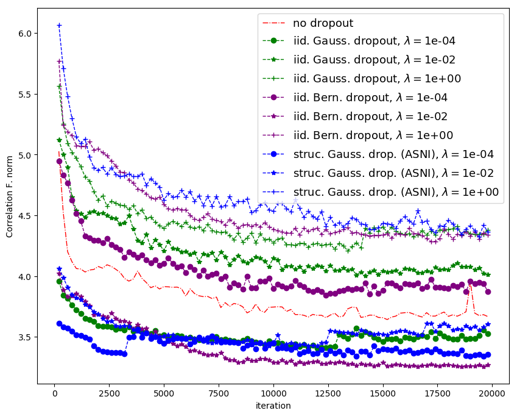

```python
sns.reset_orig()


fig, ax = plt.subplots(figsize=(10, 8))

ax.plot(np.arange(200, max_iters, 200), cor_linear_2[0][1:], linestyle='-.',
        linewidth=1, color='red', label='no dropout')

line_styles = ['--o', '--*', '--+']


for i, series in enumerate(cor_iid_2):
    ax.plot(np.arange(200, max_iters, 200), series[1:],
            line_styles[i], color='green', linewidth=1,
            label=r'iid. Gauss. dropout, $\lambda=$%.0e'  %  lambdas[i])

for i, series in enumerate(cor_iid_2_bern):
    ax.plot(np.arange(200, max_iters, 200), series[1:],
            line_styles[i], color='purple', linewidth=1,
            label=r'iid. Bern. dropout, $\lambda=$%.0e'  %  lambdas[i])



for i, series in enumerate(cor_struc_2):
    ax.plot(np.arange(200, max_iters, 200), series[1:],
            line_styles[i], color='blue', linewidth=1,
            label=r'struc. Gauss. drop. (ASNI), $\lambda=$%.0e' % lambdas[i])


ax.set_xlabel('iteration')
ax.set_ylabel('Correlation F. norm')

# ax.set_ylim([0.8, 1.0])

plt.legend(prop={'size': 13})
plt.show()
```

Now if we perform iid and structured nois injection only on the last layer :

```python
nb_hidden1= 256
nb_hidden2= 128
dim=dimension
class MLP_2:

    def __init__(self, dim, nb_hidden1,nb_hidden2, nb_classes, batch_size, l, mode=None):

        self.X = tf.placeholder(tf.float32, [None, dimension])
        self.Y = tf.placeholder(tf.float32, [None, nb_classes])
        self.train = tf.placeholder(tf.bool)

        W1 = tf.Variable(tf.random_uniform([dim, nb_hidden1], -0.01, 0.01))
        b1 = tf.Variable(tf.zeros(shape=[nb_hidden1]))

       #self.dl1 = tf.cond(self.train, lambda : dropout_layer(self.X, mode, l, dimension), lambda : self.X)
        self.dl1 = self.X
        self.err1 = self.dl1 - self.X
        self.act1 = tf.nn.relu(tf.matmul(self.dl1, W1) + b1)

        W2 = tf.Variable(tf.random_uniform([nb_hidden1, nb_hidden2], -0.01, 0.01))
        b2 = tf.Variable(tf.zeros(shape=[nb_hidden2]))

       #self.dl2 = tf.cond(self.train, lambda : dropout_layer(self.act1, mode, l, nb_hidden1), lambda : self.act1)
        self.dl2=self.act1
        self.err2 = self.dl2 - self.act1
        self.act2 = tf.nn.relu(tf.matmul(self.dl2, W2) + b2)

        W3 = tf.Variable(tf.random_uniform([nb_hidden2, nb_classes], -0.01, 0.01))
        b3 = tf.Variable(tf.zeros(shape=[nb_classes]))

        x = tf.cond(self.train, lambda : dropout_layer(self.act2, mode, l, nb_hidden2), lambda : self.act2)
        x = tf.matmul(x, W3) + b3

        # Minimize error using cross entropy
        self.probs = tf.nn.softmax(x)
        log_loss = tf.nn.softmax_cross_entropy_with_logits_v2(logits=x, labels=self.Y)
        self.mean_log_loss = tf.reduce_mean(log_loss)



max_iters = 20000
lambdas = [1e-4,1e-2,1e-0]


print('#### No dropout ####')
acc_linear, cor_linear_1 , acts1_linear,cor_linear_2 , acts_linear_2 = training([None], None, max_iters)

print('#### Structured dropout ####')
acc_struc, cor_struc_1, acts1_struc, cor_struc_2 , acts_stuc_2= training(lambdas, 'struc', max_iters)

print('#### IID dropout ####')
acc_iid,cor_iid_1, acts1_iid, cor_iid_2 , acts_iid_2= training(lambdas, 'iid', max_iters)

print('#### IID bern dropout ####')
acc_iid_bern,cor_iid_1_bern, acts1_iid_bern, cor_iid_2_bern , acts_iid_2_bern = training(lambdas, 'iid_bern', max_iters)
```

```
#### No dropout ####
Lamb None
Iteration: 0, 2.303
Accuracy: 0.276
Iteration: 200, 0.744
Accuracy: 0.855
Iteration: 400, 0.636
Accuracy: 0.886
Iteration: 600, 0.539
Accuracy: 0.892
Iteration: 800, 0.367
Accuracy: 0.919
Iteration: 1000, 0.175
Accuracy: 0.925
Iteration: 1200, 0.500
Accuracy: 0.934
Iteration: 1400, 0.098
Accuracy: 0.944
Iteration: 1600, 0.054
Accuracy: 0.949
Iteration: 1800, 0.139
Accuracy: 0.949
Iteration: 2000, 0.077
Accuracy: 0.950
Iteration: 2200, 0.048
Accuracy: 0.954
Iteration: 2400, 0.182
Accuracy: 0.959
Iteration: 2600, 0.087
Accuracy: 0.961
Iteration: 2800, 0.051
Accuracy: 0.960
Iteration: 3000, 0.018
Accuracy: 0.962
Iteration: 3200, 0.227
Accuracy: 0.966
Iteration: 3400, 0.122
Accuracy: 0.966
Iteration: 3600, 0.042
Accuracy: 0.960
```

[output cut: 1959 more lines]

```
Accuracy: 0.980
Iteration: 18600, 0.000
Accuracy: 0.981
Iteration: 18800, 0.000
Accuracy: 0.980
Iteration: 19000, 0.009
Accuracy: 0.981
Iteration: 19200, 0.027
Accuracy: 0.978
Iteration: 19400, 0.000
Accuracy: 0.978
Iteration: 19600, 0.000
Accuracy: 0.978
Iteration: 19800, 0.001
Accuracy: 0.981
```

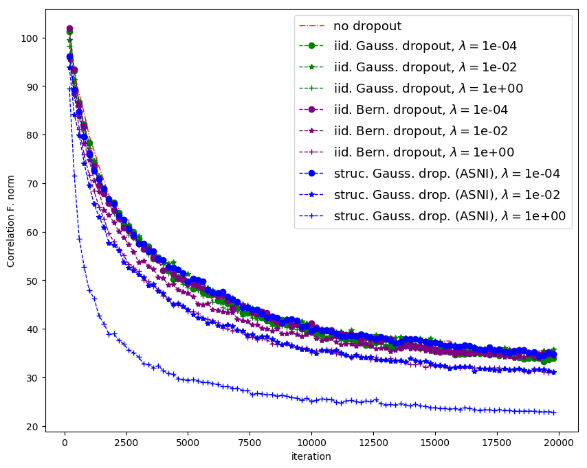

```python
sns.reset_orig()


fig, ax = plt.subplots(figsize=(10, 8))

ax.plot(np.arange(200, max_iters, 200), cor_linear_1[0][1:], linestyle='-.',
        linewidth=1, color='red', label='no dropout')

line_styles = ['--o', '--*', '--+']


for i, series in enumerate(cor_iid_1):
    ax.plot(np.arange(200, max_iters, 200), series[1:],
            line_styles[i], color='green', linewidth=1,
            label=r'iid. Gauss. dropout, $\lambda=$%.0e'  %  lambdas[i])


for i, series in enumerate(cor_iid_1_bern):
    ax.plot(np.arange(200, max_iters, 200), series[1:],
            line_styles[i], color='purple', linewidth=1,
            label=r'iid. Bern. dropout, $\lambda=$%.0e'  %  lambdas[i])


for i, series in enumerate(cor_struc_1):
    ax.plot(np.arange(200, max_iters, 200), series[1:],
            line_styles[i], color='blue', linewidth=1,
            label=r'struc. Gauss. drop. (ASNI), $\lambda=$%.0e' % lambdas[i])


ax.set_xlabel('iteration')
ax.set_ylabel('Correlation F. norm')

# ax.set_ylim([0.8, 1.0])

plt.legend(ncol=1,prop={'size': 13})
plt.show()
```

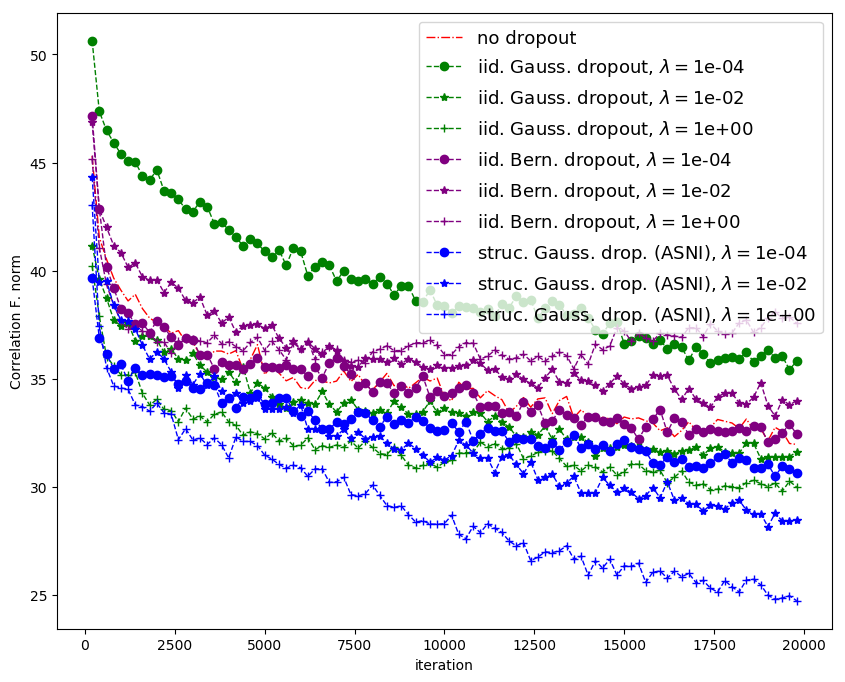

```python
sns.reset_orig()


fig, ax = plt.subplots(figsize=(10, 8))

ax.plot(np.arange(200, max_iters, 200), cor_linear_2[0][1:], linestyle='-.',
        linewidth=1, color='red', label='no dropout')

line_styles = ['--o', '--*', '--+']


for i, series in enumerate(cor_iid_2):
    ax.plot(np.arange(200, max_iters, 200), series[1:],
            line_styles[i], color='green', linewidth=1,
            label=r'iid. Gauss. dropout, $\lambda=$%.0e'  %  lambdas[i])

for i, series in enumerate(cor_iid_2_bern):
    ax.plot(np.arange(200, max_iters, 200), series[1:],
            line_styles[i], color='purple', linewidth=1,
            label=r'iid. Bern. dropout, $\lambda=$%.0e'  %  lambdas[i])



for i, series in enumerate(cor_struc_2):
    ax.plot(np.arange(200, max_iters, 200), series[1:],
            line_styles[i], color='blue', linewidth=1,
            label=r'struc. Gauss. drop. (ASNI), $\lambda=$%.0e' % lambdas[i])


ax.set_xlabel('iteration')
ax.set_ylabel('Correlation F. norm')

# ax.set_ylim([0.8, 1.0])

plt.legend(prop={'size': 13})
plt.show()
```

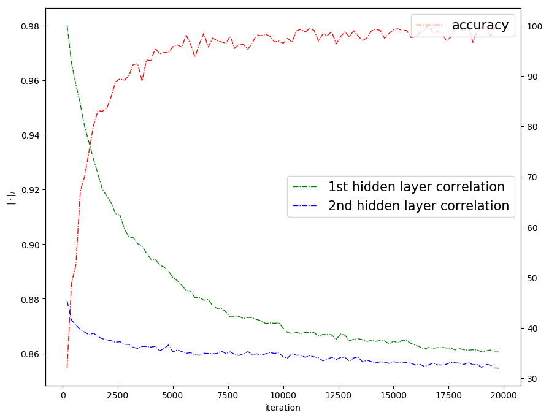

```python
sns.reset_orig()
max_iters=20000

fig, ax = plt.subplots(figsize=(10, 8))

ax.plot(np.arange(200, max_iters, 200), acc_linear[0][1:] , linestyle='-.',
        linewidth=1, color='red', label='accuracy')

ax.legend(loc=1, prop={'size': 15})

ax2 = ax.twinx()

ax2.plot(np.arange(200, max_iters, 200),  cor_linear_1[0][1:] , linestyle='-.',
        linewidth=1, color='green', label='1st hidden layer correlation')

ax2.plot(np.arange(200, max_iters, 200),  cor_linear_2[0][1:] , linestyle='-.',
        linewidth=1, color='blue', label='2nd hidden layer correlation')


ax.set_xlabel('iteration')
ax.set_ylabel('$|\cdot|_F$')

#ax.set_ylim([0.8, 1.0])

ax2.legend(loc=7, prop={'size': 15})
plt.show()
```

It is interesting here to note that structured dropout decorrelates both hidden layers, however it does decorrelate the second hidden layer activations, where it is applied, more than it did when applied on the first hidden layer, and it does decorrelate the first hidden layer less than when it was applied only on this layer.

Note here that : we didn't look for the best parameter value for accuracy, see the previous markdowns and the paper for the best accuracy comparaison.

We can conlcude that: if one wants only to have decorrelated representations on one or several layers (which will be generally the last layers of the networks), structured dropout can be applied only on those layers. If one want to improve generalisation, structured dropout may be useful for all layers and several dropout rates should be searched. We showed in the ASNI report that moderately small values of $\lambda$ work well. There remains many questions in this line of work.

We are not saying that there is a causal link between correlations of the hidden layers and accuracy, but the same dynamics are happening by the optimisation proccess that one can try to enhance its effect on the decorrelation hoping that it will also have an effect on the accuracy

```python
nb_hidden1= 256
nb_hidden2= 128
dim=dimension
class MLP_2:

    def __init__(self, dim, nb_hidden1,nb_hidden2, nb_classes, batch_size, l, mode=None):

        self.X = tf.placeholder(tf.float32, [None, dimension])
        self.Y = tf.placeholder(tf.float32, [None, nb_classes])
        self.train = tf.placeholder(tf.bool)

        W1 = tf.Variable(tf.random_uniform([dim, nb_hidden1], -0.01, 0.01))
        b1 = tf.Variable(tf.zeros(shape=[nb_hidden1]))

        self.dl1 = tf.cond(self.train, lambda : dropout_layer(self.X, mode, l, dimension), lambda : self.X)
        self.err1 = self.dl1 - self.X
        self.act1 = tf.nn.relu(tf.matmul(self.dl1, W1) + b1)

        W2 = tf.Variable(tf.random_uniform([nb_hidden1, nb_hidden2], -0.01, 0.01))
        b2 = tf.Variable(tf.zeros(shape=[nb_hidden2]))

        #self.dl2 = tf.cond(self.train, lambda : dropout_layer(self.act1, mode, l, nb_hidden1), lambda : self.act1)
        self.dl2=self.act1
        self.err2 = self.dl2 - self.act1
        self.act2 = tf.nn.relu(tf.matmul(self.dl2, W2) + b2)

        W3 = tf.Variable(tf.random_uniform([nb_hidden2, nb_classes], -0.01, 0.01))
        b3 = tf.Variable(tf.zeros(shape=[nb_classes]))

        #x = tf.cond(self.train, lambda : dropout_layer(self.act2, mode, l, nb_hidden2), lambda : self.act2)
        x=self.act2
        x = tf.matmul(x, W3) + b3

        # Minimize error using cross entropy
        self.probs = tf.nn.softmax(x)
        log_loss = tf.nn.softmax_cross_entropy_with_logits_v2(logits=x, labels=self.Y)
        self.mean_log_loss = tf.reduce_mean(log_loss)



max_iters = 20000
lambdas = [1e-4,1e-2,1e-0]


print('#### No dropout ####')
acc_linear, cor_linear_1 , acts1_linear,cor_linear_2 , acts_linear_2 = training([None], None, max_iters)

print('#### Structured dropout ####')
acc_struc, cor_struc_1, acts1_struc, cor_struc_2 , acts_stuc_2= training(lambdas, 'struc', max_iters)

print('#### IID dropout ####')
acc_iid,cor_iid_1, acts1_iid, cor_iid_2 , acts_iid_2= training(lambdas, 'iid', max_iters)

print('#### IID bern dropout ####')
acc_iid_bern,cor_iid_1_bern, acts1_iid_bern, cor_iid_2_bern , acts_iid_2_bern = training(lambdas, 'iid_bern', max_iters)
```

```
#### No dropout ####
Lamb None
Iteration: 0, 2.303
Accuracy: 0.167
Iteration: 200, 0.560
Accuracy: 0.830
Iteration: 400, 0.343
Accuracy: 0.887
Iteration: 600, 0.576
Accuracy: 0.916
Iteration: 800, 0.093
Accuracy: 0.919
Iteration: 1000, 0.071
Accuracy: 0.939
Iteration: 1200, 0.056
Accuracy: 0.937
Iteration: 1400, 0.117
Accuracy: 0.945
Iteration: 1600, 0.085
Accuracy: 0.951
Iteration: 1800, 0.117
Accuracy: 0.953
Iteration: 2000, 0.059
Accuracy: 0.956
Iteration: 2200, 0.323
Accuracy: 0.961
Iteration: 2400, 0.315
Accuracy: 0.954
Iteration: 2600, 0.073
Accuracy: 0.956
Iteration: 2800, 0.086
Accuracy: 0.966
Iteration: 3000, 0.058
Accuracy: 0.958
Iteration: 3200, 0.048
Accuracy: 0.965
Iteration: 3400, 0.074
Accuracy: 0.964
Iteration: 3600, 0.020
Accuracy: 0.967
```

[output cut: 1959 more lines]

```
Accuracy: 0.981
Iteration: 18600, 0.138
Accuracy: 0.981
Iteration: 18800, 0.135
Accuracy: 0.981
Iteration: 19000, 0.216
Accuracy: 0.983
Iteration: 19200, 0.018
Accuracy: 0.981
Iteration: 19400, 0.013
Accuracy: 0.982
Iteration: 19600, 0.380
Accuracy: 0.982
Iteration: 19800, 0.307
Accuracy: 0.981
```

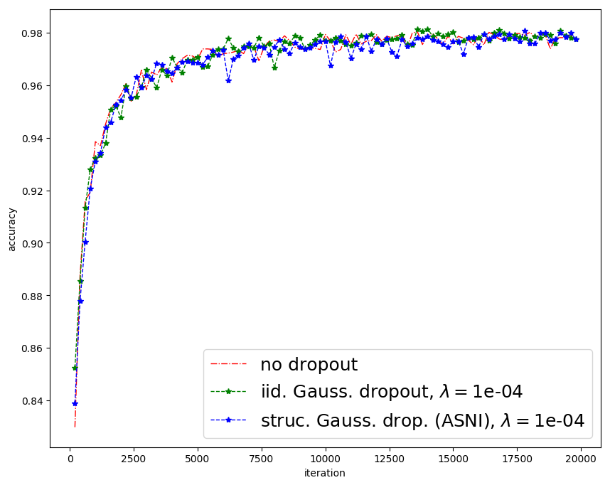

```python
sns.reset_orig()

fig, ax = plt.subplots(figsize=(10, 8))

ax.plot(np.arange(200, max_iters, 200), acc_linear[0][1:], linestyle='-.',
        linewidth=1, color='red', label='no dropout')

line_styles = ['--o', '--*', '--']


best_iid = np.argmax([np.max(accs) for accs in acc_iid])

ax.plot(np.arange(200, max_iters, 200), acc_iid[best_iid][1:],
            line_styles[1], color='green', linewidth=1,
            label=r'iid. Gauss. dropout, $\lambda=$%.0e' % lambdas[best_iid])

best_struc = np.argmax([np.max(accs) for accs in acc_struc])

ax.plot(np.arange(200, max_iters, 200), acc_struc[best_struc][1:],
            line_styles[1], color='blue', linewidth=1,
            label=r'struc. Gauss. drop. (ASNI), $\lambda=$%.0e' % lambdas[best_struc])



ax.set_xlabel('iteration')
ax.set_ylabel('accuracy')

# ax.set_ylim([0.8, 1.0])

plt.legend(prop={'size': 18})
plt.show()
```

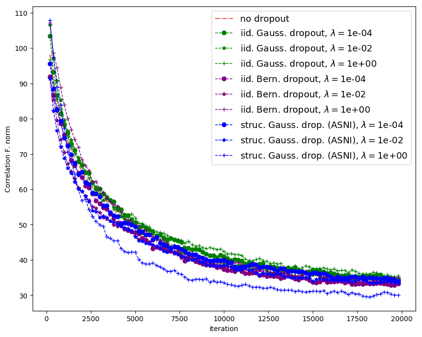

```python
sns.reset_orig()


fig, ax = plt.subplots(figsize=(10, 8))

ax.plot(np.arange(200, max_iters, 200), cor_linear_1[0][1:], linestyle='-.',
        linewidth=1, color='red', label='no dropout')

line_styles = ['--o', '--*', '--+']


for i, series in enumerate(cor_iid_1):
    ax.plot(np.arange(200, max_iters, 200), series[1:],
            line_styles[i], color='green', linewidth=1,
            label=r'iid. Gauss. dropout, $\lambda=$%.0e'  %  lambdas[i])


for i, series in enumerate(cor_iid_1_bern):
    ax.plot(np.arange(200, max_iters, 200), series[1:],
            line_styles[i], color='purple', linewidth=1,
            label=r'iid. Bern. dropout, $\lambda=$%.0e'  %  lambdas[i])


for i, series in enumerate(cor_struc_1):
    ax.plot(np.arange(200, max_iters, 200), series[1:],
            line_styles[i], color='blue', linewidth=1,
            label=r'struc. Gauss. drop. (ASNI), $\lambda=$%.0e' % lambdas[i])


ax.set_xlabel('iteration')
ax.set_ylabel('Correlation F. norm')

# ax.set_ylim([0.8, 1.0])

plt.legend(ncol=1,prop={'size': 13})
plt.show()
```

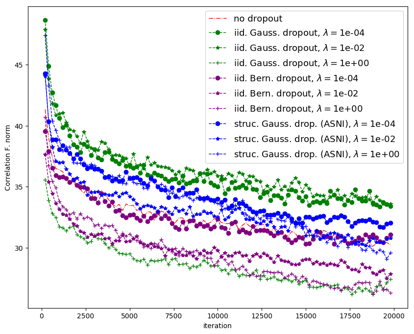

```python
sns.reset_orig()


fig, ax = plt.subplots(figsize=(10, 8))

ax.plot(np.arange(200, max_iters, 200), cor_linear_2[0][1:], linestyle='-.',
        linewidth=1, color='red', label='no dropout')

line_styles = ['--o', '--*', '--+']


for i, series in enumerate(cor_iid_2):
    ax.plot(np.arange(200, max_iters, 200), series[1:],
            line_styles[i], color='green', linewidth=1,
            label=r'iid. Gauss. dropout, $\lambda=$%.0e'  %  lambdas[i])

for i, series in enumerate(cor_iid_2_bern):
    ax.plot(np.arange(200, max_iters, 200), series[1:],
            line_styles[i], color='purple', linewidth=1,
            label=r'iid. Bern. dropout, $\lambda=$%.0e'  %  lambdas[i])



for i, series in enumerate(cor_struc_2):
    ax.plot(np.arange(200, max_iters, 200), series[1:],
            line_styles[i], color='blue', linewidth=1,
            label=r'struc. Gauss. drop. (ASNI), $\lambda=$%.0e' % lambdas[i])


ax.set_xlabel('iteration')
ax.set_ylabel('Correlation F. norm')

# ax.set_ylim([0.8, 1.0])

plt.legend(prop={'size': 13})
plt.show()
```

[figure not shown]

```python
fig, axes = plt.subplots(figsize=(12, 16), ncols=4, nrows=3)

_ = axes[0][3].hist(acts1_linear[0][-1].flatten())
axes[0][3].set_title(r'weights without INI')

_ = axes[0][0].hist(acts1_iid[0][-1].flatten())
axes[0][0].set_title(r'$\lambda = %0.0E$ iid Gauss. drop. weights' % lambdas[0])
_ = axes[0][1].hist(acts1_struc[0][-1].flatten())
axes[0][1].set_title(r'$\lambda = %0.0E$ struc. Gauss. drop. weights' % lambdas[0])
_ = axes[1][0].hist(acts1_iid[1][-1].flatten())
axes[1][0].set_title(r'$\lambda = %0.0E$  iid Gauss. drop. weights' % lambdas[1])
_ = axes[1][1].hist(acts1_struc[1][-1].flatten())
axes[1][1].set_title(r'$\lambda = %0.0E$ struc Gauss. drop. weights' % lambdas[1])
_ = axes[2][0].hist(acts1_iid[2][-1].flatten())
axes[2][0].set_title(r'$\lambda = %0.0E$ iid Gauss. drop. weights' % lambdas[2])
_ = axes[2][1].hist(acts1_struc[2][-1].flatten())
axes[2][1].set_title(r'$\lambda = %0.0E$ struc Gauss. drop. weights' % lambdas[2])
_ = axes[0][2].hist(acts1_iid[1][-1].flatten())
axes[0][2].set_title(r'$\lambda = %0.0E$  iid Bern. drop. weights' % lambdas[1])
_ = axes[1][2].hist(acts1_iid[1][-1].flatten())
axes[1][2].set_title(r'$\lambda = %0.0E$  iid Bern. drop. weights' % lambdas[1])
_ = axes[2][2].hist(acts1_iid[1][-1].flatten())
axes[2][2].set_title(r'$\lambda = %0.0E$  iid Bern. drop. weights' % lambdas[1])
plt.show()
```

We now train and test the same network architecture with dropout and structured dropout applied on both hidden layers and on the input layer all together.

```python
nb_hidden1= 256
nb_hidden2= 128
dim=dimension
class MLP_2:

    def __init__(self, dim, nb_hidden1,nb_hidden2, nb_classes, batch_size, l, mode=None):

        self.X = tf.placeholder(tf.float32, [None, dimension])
        self.Y = tf.placeholder(tf.float32, [None, nb_classes])
        self.train = tf.placeholder(tf.bool)

        W1 = tf.Variable(tf.random_uniform([dim, nb_hidden1], -0.01, 0.01))
        b1 = tf.Variable(tf.zeros(shape=[nb_hidden1]))

        self.dl1 = tf.cond(self.train, lambda : dropout_layer(self.X, mode, l, dimension), lambda : self.X)
        self.err1 = self.dl1 - self.X
        self.act1 = tf.nn.relu(tf.matmul(self.dl1, W1) + b1)

        W2 = tf.Variable(tf.random_uniform([nb_hidden1, nb_hidden2], -0.01, 0.01))
        b2 = tf.Variable(tf.zeros(shape=[nb_hidden2]))

        self.dl2 = tf.cond(self.train, lambda : dropout_layer(self.act1, mode, l, nb_hidden1), lambda : self.act1)
        #self.dl2=self.act1
        self.err2 = self.dl2 - self.act1
        self.act2 = tf.nn.relu(tf.matmul(self.dl2, W2) + b2)

        W3 = tf.Variable(tf.random_uniform([nb_hidden2, nb_classes], -0.01, 0.01))
        b3 = tf.Variable(tf.zeros(shape=[nb_classes]))

        x = tf.cond(self.train, lambda : dropout_layer(self.act2, mode, l, nb_hidden2), lambda : self.act2)
        #x=self.act2
        x = tf.matmul(x, W3) + b3

        # Minimize error using cross entropy
        self.probs = tf.nn.softmax(x)
        log_loss = tf.nn.softmax_cross_entropy_with_logits_v2(logits=x, labels=self.Y)
        self.mean_log_loss = tf.reduce_mean(log_loss)



max_iters = 20000
lambdas = [1e-4,1e-2,1e-0]


print('#### No dropout ####')
acc_linear, cor_linear_1 , acts1_linear,cor_linear_2 , acts_linear_2 = training([None], None, max_iters)

print('#### Structured dropout ####')
acc_struc, cor_struc_1, acts1_struc, cor_struc_2 , acts_stuc_2= training(lambdas, 'struc', max_iters)

print('#### IID dropout ####')
acc_iid,cor_iid_1, acts1_iid, cor_iid_2 , acts_iid_2= training(lambdas, 'iid', max_iters)

print('#### IID bern dropout ####')
acc_iid_bern,cor_iid_1_bern, acts1_iid_bern, cor_iid_2_bern , acts_iid_2_bern = training(lambdas, 'iid_bern', max_iters)
```

```
#### No dropout ####
Lamb None
Iteration: 0, 2.303
Accuracy: 0.156
Iteration: 200, 0.454
Accuracy: 0.834
Iteration: 400, 0.445
Accuracy: 0.890
Iteration: 600, 0.377
Accuracy: 0.904
Iteration: 800, 0.403
Accuracy: 0.914
Iteration: 1000, 0.244
Accuracy: 0.927
Iteration: 1200, 0.143
Accuracy: 0.933
Iteration: 1400, 0.208
Accuracy: 0.925
Iteration: 1600, 0.187
Accuracy: 0.945
Iteration: 1800, 0.161
Accuracy: 0.953
Iteration: 2000, 0.045
Accuracy: 0.952
Iteration: 2200, 0.299
Accuracy: 0.955
Iteration: 2400, 0.015
Accuracy: 0.959
Iteration: 2600, 0.106
Accuracy: 0.959
Iteration: 2800, 0.015
Accuracy: 0.959
Iteration: 3000, 0.012
Accuracy: 0.963
Iteration: 3200, 0.039
Accuracy: 0.965
Iteration: 3400, 0.114
Accuracy: 0.963
Iteration: 3600, 0.018
Accuracy: 0.965
```

[output cut: 1959 more lines]

```
Accuracy: 0.972
Iteration: 18600, 0.160
Accuracy: 0.967
Iteration: 18800, 0.250
Accuracy: 0.973
Iteration: 19000, 0.322
Accuracy: 0.972
Iteration: 19200, 0.481
Accuracy: 0.972
Iteration: 19400, 0.113
Accuracy: 0.971
Iteration: 19600, 0.233
Accuracy: 0.970
Iteration: 19800, 0.093
Accuracy: 0.970
```

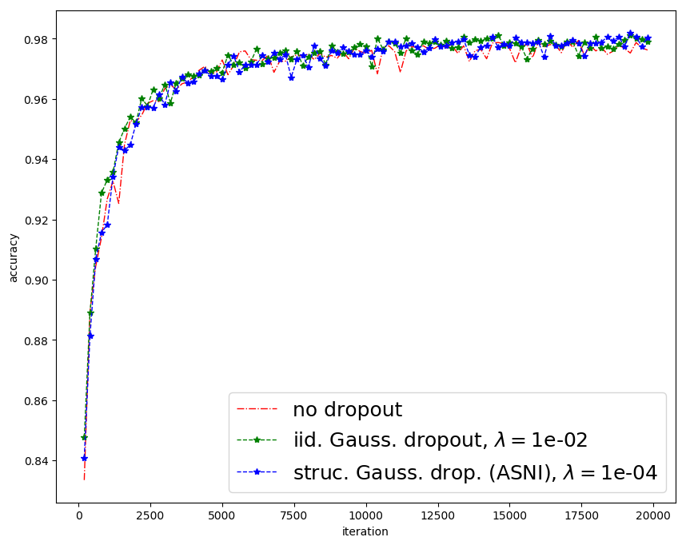

```python
sns.reset_orig()

fig, ax = plt.subplots(figsize=(10, 8))

ax.plot(np.arange(200, max_iters, 200), acc_linear[0][1:], linestyle='-.',
        linewidth=1, color='red', label='no dropout')

line_styles = ['--o', '--*', '--']


best_iid = np.argmax([np.max(accs) for accs in acc_iid])

ax.plot(np.arange(200, max_iters, 200), acc_iid[best_iid][1:],
            line_styles[1], color='green', linewidth=1,
            label=r'iid. Gauss. dropout, $\lambda=$%.0e' % lambdas[best_iid])

best_struc = np.argmax([np.max(accs) for accs in acc_struc])

ax.plot(np.arange(200, max_iters, 200), acc_struc[best_struc][1:],
            line_styles[1], color='blue', linewidth=1,
            label=r'struc. Gauss. drop. (ASNI), $\lambda=$%.0e' % lambdas[best_struc])



ax.set_xlabel('iteration')
ax.set_ylabel('accuracy')

# ax.set_ylim([0.8, 1.0])

plt.legend(prop={'size': 18})
plt.show()
```

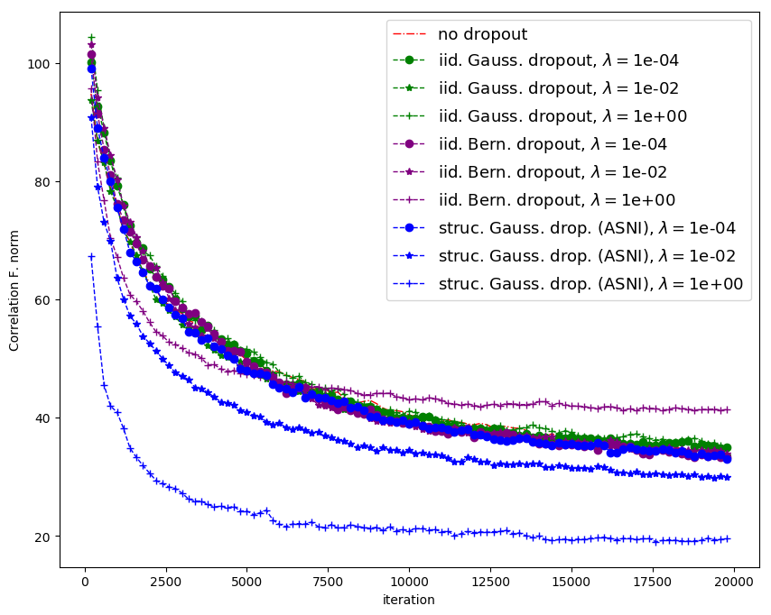

```python
sns.reset_orig()


fig, ax = plt.subplots(figsize=(10, 8))

ax.plot(np.arange(200, max_iters, 200), cor_linear_1[0][1:], linestyle='-.',
        linewidth=1, color='red', label='no dropout')

line_styles = ['--o', '--*', '--+']


for i, series in enumerate(cor_iid_1):
    ax.plot(np.arange(200, max_iters, 200), series[1:],
            line_styles[i], color='green', linewidth=1,
            label=r'iid. Gauss. dropout, $\lambda=$%.0e'  %  lambdas[i])


for i, series in enumerate(cor_iid_1_bern):
    ax.plot(np.arange(200, max_iters, 200), series[1:],
            line_styles[i], color='purple', linewidth=1,
            label=r'iid. Bern. dropout, $\lambda=$%.0e'  %  lambdas[i])


for i, series in enumerate(cor_struc_1):
    ax.plot(np.arange(200, max_iters, 200), series[1:],
            line_styles[i], color='blue', linewidth=1,
            label=r'struc. Gauss. drop. (ASNI), $\lambda=$%.0e' % lambdas[i])


ax.set_xlabel('iteration')
ax.set_ylabel('Correlation F. norm')

# ax.set_ylim([0.8, 1.0])

plt.legend(ncol=1,prop={'size': 13})
plt.show()
```

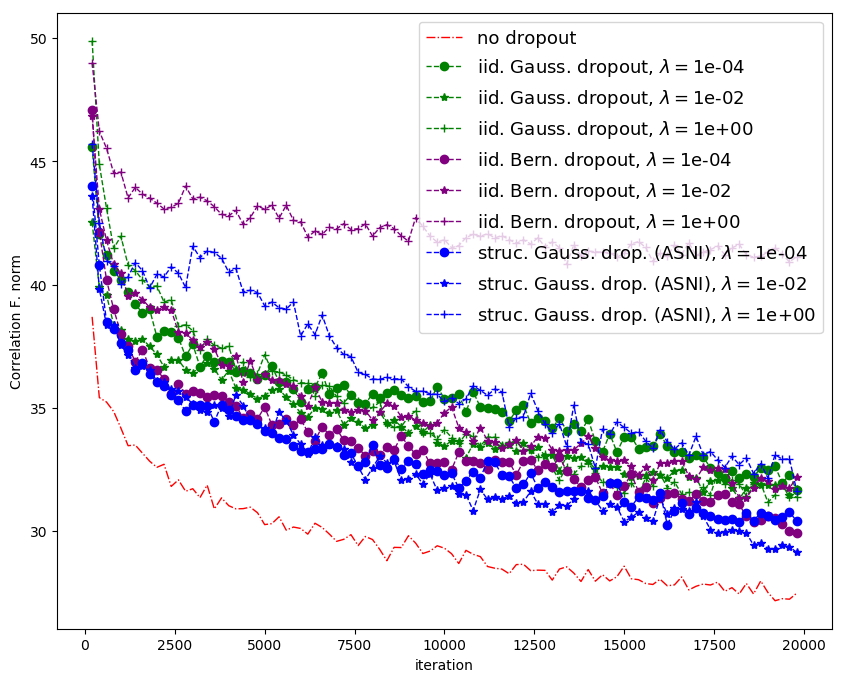

```python
sns.reset_orig()


fig, ax = plt.subplots(figsize=(10, 8))

ax.plot(np.arange(200, max_iters, 200), cor_linear_2[0][1:], linestyle='-.',
        linewidth=1, color='red', label='no dropout')

line_styles = ['--o', '--*', '--+']


for i, series in enumerate(cor_iid_2):
    ax.plot(np.arange(200, max_iters, 200), series[1:],
            line_styles[i], color='green', linewidth=1,
            label=r'iid. Gauss. dropout, $\lambda=$%.0e'  %  lambdas[i])

for i, series in enumerate(cor_iid_2_bern):
    ax.plot(np.arange(200, max_iters, 200), series[1:],
            line_styles[i], color='purple', linewidth=1,
            label=r'iid. Bern. dropout, $\lambda=$%.0e'  %  lambdas[i])



for i, series in enumerate(cor_struc_2):
    ax.plot(np.arange(200, max_iters, 200), series[1:],
            line_styles[i], color='blue', linewidth=1,
            label=r'struc. Gauss. drop. (ASNI), $\lambda=$%.0e' % lambdas[i])


ax.set_xlabel('iteration')
ax.set_ylabel('Correlation F. norm')

# ax.set_ylim([0.8, 1.0])

plt.legend(prop={'size': 13})
plt.show()
```

[figure not shown]

```python
fig, axes = plt.subplots(figsize=(12, 16), ncols=4, nrows=3)

_ = axes[0][3].hist(acts1_linear[0][-1].flatten())
axes[0][3].set_title(r' without drop.')
_ = axes[1][3].hist(acts1_linear[0][-1].flatten())
axes[1][3].set_title(r' without drop.')
_ = axes[2][3].hist(acts1_linear[0][-1].flatten())
axes[2][3].set_title(r' without drop.')

_ = axes[0][1].hist(acts1_iid[0][-1].flatten())
axes[0][1].set_title(r'$\lambda = %0.0E$ iid Gauss. drop.' % lambdas[0])
_ = axes[0][0].hist(acts1_struc[0][-1].flatten())
axes[0][0].set_title(r'$\lambda = %0.0E$ struc. Gauss. drop.' % lambdas[0])
_ = axes[1][1].hist(acts1_iid[1][-1].flatten())
axes[1][1].set_title(r'$\lambda = %0.0E$  iid Gauss. drop.' % lambdas[1])
_ = axes[1][0].hist(acts1_struc[1][-1].flatten())
axes[1][0].set_title(r'$\lambda = %0.0E$ struc Gauss. drop.' % lambdas[1])
_ = axes[2][1].hist(acts1_iid[2][-1].flatten())
axes[2][1].set_title(r'$\lambda = %0.0E$ iid Gauss. drop.' % lambdas[2])
_ = axes[2][0].hist(acts1_struc[2][-1].flatten())
axes[2][0].set_title(r'$\lambda = %0.0E$ struc Gauss. drop.' % lambdas[2])
_ = axes[0][2].hist(acts1_iid[1][-1].flatten())
axes[0][2].set_title(r'$\lambda = %0.0E$  iid Bern. drop.' % lambdas[2])
_ = axes[1][2].hist(acts1_iid[1][-1].flatten())
axes[1][2].set_title(r'$\lambda = %0.0E$  iid Bern. drop.' % lambdas[2])
_ = axes[2][2].hist(acts1_iid[1][-1].flatten())
axes[2][2].set_title(r'$\lambda = %0.0E$  iid Bern. drop.' % lambdas[2])
plt.show()
```